# VEREP Property Development Analysis

Strategic Assessment of Development Opportunities

Author

HDAdvisors

Published

November 13, 2025

# Executive Summary

**Key Findings**

**Top Insights:**

- **151 properties** score in Tier 1-2 (strong development potential)
- **Primary opportunities:** Underutilized parking lots and open space
- **Average parcel size:** 5.21 acres
- **Congregations with declining pledges:** 0 properties show high financial need

**🔗 Full Interactive Dashboard**

For advanced exploration and analysis, launch the **[Full Interactive Dashboard](http://localhost:3838/)** which includes:

- Real-time filtering and property comparison
- Detailed property profiles with score breakdowns
- Export functionality (PowerPoint, Excel)
- Advanced visualization tools

*Run the dashboard by executing `shiny::runApp("app.R")` in your R console*

# Interactive Property Explorer

Use the controls below to explore properties based on your criteria. The map and table update in real-time as you adjust the filters.

Development Score Range:

Development Tiers:

Tier 2: Strong Potential

Tier 3: Moderate Potential

Tier 4: Limited Potential

Tier 5: Not Recommended

Tier 1: High Priority

Property Size (acres):

Show Top N Properties:

- Map View

- Table View

- Score Distribution

[interactive chart not shown]

**Properties Currently Displayed:**

# Key Findings

## Significant Underutilized Assets

**151 properties** score in Tier 1-2, representing substantial untapped value across the diocese. Primary opportunities exist in:

- **Parking lots** (highest development scores): Structured parking with mixed-use above can maximize land value while maintaining or increasing parking capacity
- **Open space parcels**: Well-located vacant land ideal for ground lease arrangements that provide long-term revenue without property sale
- **Properties with declining congregations**: Sites where strategic development can provide financial stability through ground lease income or shared facility arrangements

### Geographic Distribution

Development opportunities are distributed across Virginia, with notable concentrations in:

- **Urban/suburban areas** with strong walkability scores (>50) and transit access
- **Markets with favorable demographics** including LIHTC-eligible census tracts
- **Transit-accessible locations** supporting reduced parking requirements and higher density development

### Financial Sustainability Imperative

**0 of the top 10 properties** are associated with congregations showing significant financial decline, with pledge revenue down 20% or more over the past decade. Strategic development can provide:

- **Long-term ground lease revenue** - Annual income from 50-99 year ground leases
- **Capital for building improvements** - Upfront payments or phased development fees
- **Sustainable financial model** - Diversified revenue supporting congregation vitality

# Methodology & Scoring Framework

## Data Sources

### VEREP Parcel Dataset

This analysis utilizes the Virginia Episcopal Real Estate Portfolio (VEREP) parcel dataset, compiled by CGS Consultants, including:

- **790 parcels** across Virginia
- Comprehensive property characteristics (size, use, zoning)
- Environmental constraints (floodplains, wetlands, easements)
- Location metrics (walkability index, transit access scores)
- Market indicators (median income, poverty rates, demographics)

### Congregation Statistics (2014-2023)

Financial and membership data provides context on congregation health:

- Sunday attendance trends over 10-year period
- Membership changes and demographic shifts
- Plate & pledge revenue tracking
- Long-term trend analysis for financial sustainability assessment

## Development Potential Scoring

Our methodology evaluates six key dimensions, each scored 0-100 and weighted by importance:

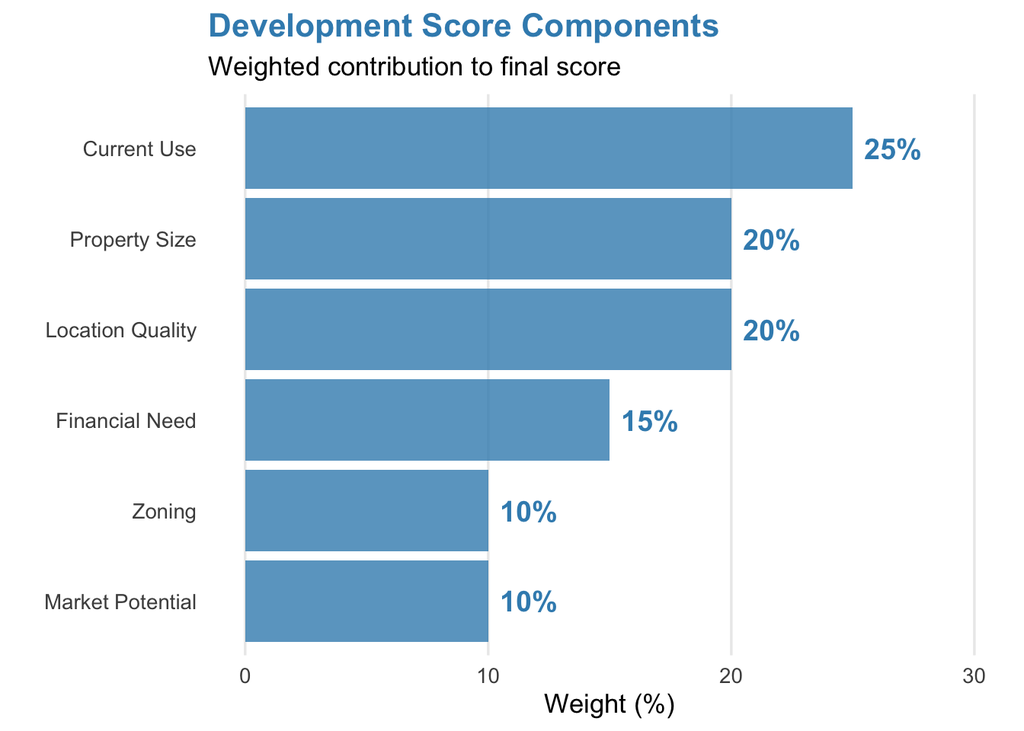

### Constraint Penalties

After calculating the weighted score, properties receive deductions for development constraints:

- **Flood zones (FEMA designated):** -40 points
- **Significant wetlands (>25% of parcel):** -35 points
- **Recorded easements:** -30 points
- **Historic district designation:** -25 points
- **Moderate wetlands (>10% of parcel):** -20 points

Final scores are capped between 0-100.

## Development Tiers

Properties are classified into five tiers based on composite scores:

| Tier | Score Range | Classification | Description |
| --- | --- | --- | --- |
| **Tier 1** | 75-100 | High Priority | Immediate development candidates with minimal barriers |
| **Tier 2** | 60-74 | Strong Potential | Near-term opportunities requiring standard due diligence |
| **Tier 3** | 45-59 | Moderate Potential | Requires creative solutions or constraint mitigation |
| **Tier 4** | 30-44 | Limited Potential | Significant barriers exist, long-term consideration only |
| **Tier 5** | <30 | Not Recommended | Unsuitable for development due to multiple constraints |

# Analysis Results

## Development Opportunity Landscape

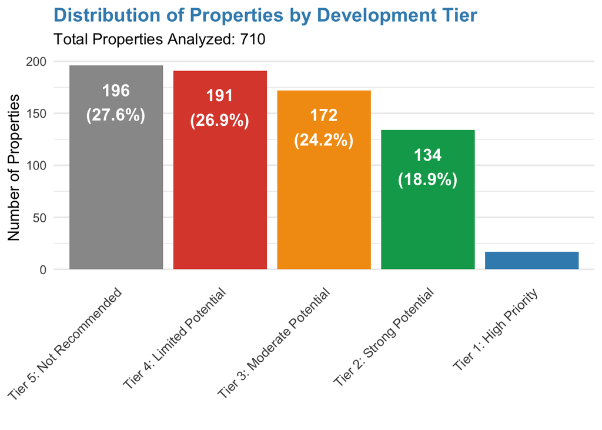

The distribution shows a healthy pipeline of development opportunities, with **151** properties in the top two tiers representing **21.3%** of the total portfolio.

## Top 10 Development Priorities

| Rank | Property Address | City | Acres | Score | Tier |
| --- | --- | --- | --- | --- | --- |
| 1 | 706 SAINT CHRISTOPHERS RD, RICHMOND 23226 | RICHMOND | 4.3 | 84.2 | Tier 1: High Priority |
| 2 | 1600 WESTBROOK AVE, RICHMOND 23227 | RICHMOND | 4.3 | 80.9 | Tier 1: High Priority |
| 3 | 600 NORTH MADISON ST, ARLINGTON 22203 | ARLINGTON | 2.0 | 80.0 | Tier 1: High Priority |
| 4 | WEST FALLS CHURCH 22042 | WEST FALLS CHURCH | 2.6 | 79.8 | Tier 1: High Priority |
| 5 | STERLING 20164 | STERLING | 2.5 | 79.5 | Tier 1: High Priority |
| 6 | CENTREVILLE 20120 | CENTREVILLE | 1.2 | 79.3 | Tier 1: High Priority |
| 7 | 1242 WEST QUEEN ST, HAMPTON 23669 | HAMPTON | 3.0 | 78.5 | Tier 1: High Priority |
| 8 | 710 ST CHRISTOPHERS RD, RICHMOND 23226 | RICHMOND | 0.6 | 78.2 | Tier 1: High Priority |
| 9 | 719 ST CHRISTOPHERS RD, RICHMOND 23226 | RICHMOND | 27.2 | 78.2 | Tier 1: High Priority |
| 10 | 5101 FILLMORE AVE, ALEXANDRIA 22311 | ALEXANDRIA | 3.4 | 76.6 | Tier 1: High Priority |

# Portfolio Statistics

## Property Use Distribution

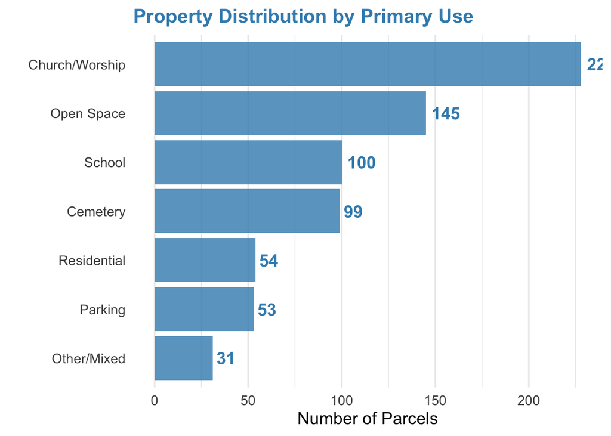

## Congregation Vitality Metrics

# Conclusion

## Strategic Opportunity Summary

The diocese portfolio contains **substantial untapped development value**, with 151 properties showing strong potential for strategic partnerships. The top 10 properties alone represent over 51.1 acres of developable land in favorable locations, with 0 sites supporting congregations facing financial sustainability challenges.

### Strategic Development Can Deliver:

✓ **Long-term revenue streams** supporting congregational vitality through ground lease arrangements  
✓ **Affordable housing creation** aligned with diocesan mission and values  
✓ **Preservation of worship space** while maximizing underutilized land value  
✓ **Capital for improvements** addressing deferred maintenance and facility needs

## Next Steps

**Recommended Actions**

1. **Commission feasibility studies** on top 3-5 properties to validate development assumptions
2. **Engage developer partners** through RFP/RFQ process for pilot project execution
3. **Launch full dashboard** for ongoing portfolio monitoring and stakeholder engagement
4. **Establish governance framework** for evaluating and approving development partnerships

## Launch Full Dashboard

For comprehensive analysis capabilities, advanced filtering, and export functionality:

**Note**

**Note:** To run the full dashboard, execute `shiny::runApp("app.R")` in your R console from the VEREP folder.

## Appendices

**Technical Methodology Details**

**Data Quality Filters Applied:**

- Minimum parcel size: 0.1 acres
- Required valid latitude/longitude coordinates
- Valid building years: 1700-2025
- Excluded parcels with insufficient data quality

**Congregation-Parcel Matching:**

Properties were matched to congregation data using the `congr_name` field. Properties without matches received neutral financial scores (30 points) to avoid penalizing properties without available congregation data.

**Missing Data Handling:**

- Missing walkability scores: Defaulted to 0
- Missing income data: Received median market scores (50)
- Properties without area or coordinates: Excluded from analysis

**Data Sources & References**

**VEREP Parcel Dataset:** Compiled by CGS Consultants  
**Congregation Statistics:** Virginia Episcopal Diocese (2014-2023)  
**Analysis Date:** 2025-11-13  
**Analyst:** HDAdvisors

*Report generated with Quarto and R. Interactive components powered by Shiny.*